# Sarcasm Detection Model Training

Trained using LSTM RNN algorithm model.

**Dataset:** News Headline Dataset for Sarcasm Detection, 44262 rows of training set and 11066 rows of testing set.

**Issue:** under-researched area of sarcasm detection; not enough time left to research further.

**Solving approach:** GloVe (Global Vectors for Word Representation) embedding approach was considered.

# Import dependencies

```python
import json
import pickle
import pandas as pd
import matplotlib.pyplot as plt
import seaborn as sns
import re

from nltk.tokenize import word_tokenize

from tensorflow import keras
from tensorflow.keras import layers
from tensorflow.keras.optimizers import SGD

from keras.preprocessing.text import Tokenizer
from keras.preprocessing.sequence import pad_sequences
from keras.regularizers import l2
from keras import regularizers
```

# Load and explore dataset

Combine datasets, preprocess them and store them in a list along with the Y labels as its own separate list.

```python
def parse_data(file):
    for line in open(file,'r'):
        yield json.loads(line)
```

Dataset 1

```python
json_data1 = list(parse_data('../datasets/Sarcasm_Headlines_Dataset.json'))
```

```python
dataset1 = pd.DataFrame(json_data1)
dataset1
```

|  | article_link | headline | is_sarcastic |
| --- | --- | --- | --- |
| 0 | https://www.huffingtonpost.com/entry/versace-b... | former versace store clerk sues over secret 'b... | 0 |
| 1 | https://www.huffingtonpost.com/entry/roseanne-... | the 'roseanne' revival catches up to our thorn... | 0 |
| 2 | https://local.theonion.com/mom-starting-to-fea... | mom starting to fear son's web series closest ... | 1 |
| 3 | https://politics.theonion.com/boehner-just-wan... | boehner just wants wife to listen, not come up... | 1 |
| 4 | https://www.huffingtonpost.com/entry/jk-rowlin... | j.k. rowling wishes snape happy birthday in th... | 0 |
| ... | ... | ... | ... |
| 26704 | https://www.huffingtonpost.com/entry/american-... | american politics in moral free-fall | 0 |
| 26705 | https://www.huffingtonpost.com/entry/americas-... | america's best 20 hikes | 0 |
| 26706 | https://www.huffingtonpost.com/entry/reparatio... | reparations and obama | 0 |
| 26707 | https://www.huffingtonpost.com/entry/israeli-b... | israeli ban targeting boycott supporters raise... | 0 |
| 26708 | https://www.huffingtonpost.com/entry/gourmet-g... | gourmet gifts for the foodie 2014 | 0 |

26709 rows × 3 columns

```python
dataset1 = dataset1.drop(columns=['article_link'])
```

```python
dataset1
```

|  | headline | is_sarcastic |
| --- | --- | --- |
| 0 | former versace store clerk sues over secret 'b... | 0 |
| 1 | the 'roseanne' revival catches up to our thorn... | 0 |
| 2 | mom starting to fear son's web series closest ... | 1 |
| 3 | boehner just wants wife to listen, not come up... | 1 |
| 4 | j.k. rowling wishes snape happy birthday in th... | 0 |
| ... | ... | ... |
| 26704 | american politics in moral free-fall | 0 |
| 26705 | america's best 20 hikes | 0 |
| 26706 | reparations and obama | 0 |
| 26707 | israeli ban targeting boycott supporters raise... | 0 |
| 26708 | gourmet gifts for the foodie 2014 | 0 |

26709 rows × 2 columns

```python
len(dataset1)
```

```
26709
```

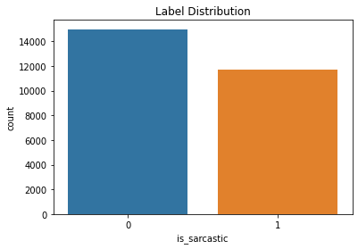

```python
ax = plt.axes()
sns.countplot(dataset1.is_sarcastic,ax=ax)
ax.set_title('Label Distribution')
plt.show()
```

```python
dataset1.headline[0]
```

```
"former versace store clerk sues over secret 'black code' for minority shoppers"
```

Dataset 2

```python
json_data2 = list(parse_data('../datasets/Sarcasm_Headlines_Dataset_v2.json'))
```

```python
dataset2 = pd.DataFrame(json_data2)
dataset2
```

|  | is_sarcastic | headline | article_link |
| --- | --- | --- | --- |
| 0 | 1 | thirtysomething scientists unveil doomsday clo... | https://www.theonion.com/thirtysomething-scien... |
| 1 | 0 | dem rep. totally nails why congress is falling... | https://www.huffingtonpost.com/entry/donna-edw... |
| 2 | 0 | eat your veggies: 9 deliciously different recipes | https://www.huffingtonpost.com/entry/eat-your-... |
| 3 | 1 | inclement weather prevents liar from getting t... | https://local.theonion.com/inclement-weather-p... |
| 4 | 1 | mother comes pretty close to using word 'strea... | https://www.theonion.com/mother-comes-pretty-c... |
| ... | ... | ... | ... |
| 28614 | 1 | jews to celebrate rosh hashasha or something | https://www.theonion.com/jews-to-celebrate-ros... |
| 28615 | 1 | internal affairs investigator disappointed con... | https://local.theonion.com/internal-affairs-in... |
| 28616 | 0 | the most beautiful acceptance speech this week... | https://www.huffingtonpost.com/entry/andrew-ah... |
| 28617 | 1 | mars probe destroyed by orbiting spielberg-gat... | https://www.theonion.com/mars-probe-destroyed-... |
| 28618 | 1 | dad clarifies this not a food stop | https://www.theonion.com/dad-clarifies-this-no... |

28619 rows × 3 columns

```python
dataset2 = dataset2.drop(columns=['article_link'])
```

```python
dataset2
```

|  | is_sarcastic | headline |
| --- | --- | --- |
| 0 | 1 | thirtysomething scientists unveil doomsday clo... |
| 1 | 0 | dem rep. totally nails why congress is falling... |
| 2 | 0 | eat your veggies: 9 deliciously different recipes |
| 3 | 1 | inclement weather prevents liar from getting t... |
| 4 | 1 | mother comes pretty close to using word 'strea... |
| ... | ... | ... |
| 28614 | 1 | jews to celebrate rosh hashasha or something |
| 28615 | 1 | internal affairs investigator disappointed con... |
| 28616 | 0 | the most beautiful acceptance speech this week... |
| 28617 | 1 | mars probe destroyed by orbiting spielberg-gat... |
| 28618 | 1 | dad clarifies this not a food stop |

28619 rows × 2 columns

```python
len(dataset2)
```

```
28619
```

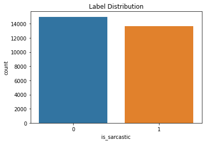

```python
ax = plt.axes()
sns.countplot(dataset2.is_sarcastic,ax=ax)
ax.set_title('Label Distribution')
plt.show()
```

```python
dataset2.headline[0]
```

```
'thirtysomething scientists unveil doomsday clock of hair loss'
```

Combine datasets

```python
frames = [dataset1, dataset2]
```

```python
dataset = pd.concat(frames)
```

# Preprocess texts

This section deals with the data preparation part where the texts are cleaned and any unnecessary characters such as certain punctuations and whitespaces are removed.

```python
dataset['headline'] = dataset['headline'].apply(lambda x: x.lower())
dataset['headline'] = dataset['headline'].apply(lambda x: re.sub(r'\d+', '', x))
dataset['headline'] = dataset['headline'].apply(lambda x: re.sub(r'[.,:;/\\$£&^*%"(){}\[\]<>#@…+-=_~|¬`]', '', x))
dataset['headline'] = dataset['headline'].apply(lambda x: re.sub(r"'", '', x))
dataset['headline'] = dataset['headline'].apply(lambda x: re.sub(r' +', ' ', x))
```

# Split data to train test

```python
train_size = int(len(dataset) - (len(dataset) * 0.2))
```

```python
train_data = dataset[:train_size]
test_data = dataset[train_size:]
```

```python
len(train_data)
```

```
44262
```

```python
len(test_data)
```

```
11066
```

```python
train_texts = train_data['headline']
test_texts = test_data['headline']
train_labels = train_data['is_sarcastic']
test_labels = test_data['is_sarcastic']
```

# Initialise parameters

Initialise the necessary data-based parameters such as maximum vocabulary words, embedding dimension, maximum sequence length, truncating and padding type as well as the OOV token.

```python
max_words = 10000 # this parameter is set to the top list of words (common words) to determine word-integer word mapping tokenisation.
embedding_dim = 32 # this parameter is set to be lower than the polarity training embedding dimension due to less words and to save time training the model.
max_len = 200 # same as the embedding dimension, this number is set to be lower due to shorter text sequences within the documents of the news headline data sample.
# The following parameters are used in the pad_sequences() function.
trunc_type = 'post' # truncate the text sequences at the end.
padding_type = 'post' # pad the text sequences from the end.
oov_tok = '<OOV>' # OOV = Out of Vocabulary, replaces unknown words with '<OOV>' token string.
```

# Tokenise

Tokenise the sequences of texts into word-integer mapping rules, replace any unknown words with OOV tokens, as well as pad and trunctae the sequences.

```python
tokenizer = Tokenizer(num_words=max_words, oov_token=oov_tok)
tokenizer.fit_on_texts(train_texts)
```

```python
train_sequences = tokenizer.texts_to_sequences(train_texts)
test_sequences = tokenizer.texts_to_sequences(test_texts)
x_train_dtm = pad_sequences(train_sequences, maxlen=max_len, padding=padding_type, truncating=trunc_type)
x_test_dtm = pad_sequences(test_sequences, maxlen=max_len, padding=padding_type, truncating=trunc_type)
```

See data shape

```python
x_train_dtm.shape
```

```
(44262, 200)
```

```python
x_test_dtm.shape
```

```
(11066, 200)
```

```python
y = pd.get_dummies(train_labels).values
print(y.shape)
```

```
(44262, 2)
```

```python
y = pd.get_dummies(test_labels).values
print(y.shape)
```

```
(11066, 2)
```

# Build and evaluate model

Initialise the LSTM model using the necessary classes from the Keras library, and set the hyperparameters as specified in the below cell.

**Best model hyperparameter tuning**  
1 layer of bidirectional LSTM with 32 units (64 units bidirectionally)  
Batch size as 32  
5 epochs

```python
model = keras.Sequential()

model.add(keras.layers.Embedding(max_words, embedding_dim))
model.add(keras.layers.Bidirectional(keras.layers.LSTM(embedding_dim)))
model.add(keras.layers.Dense(1, activation='sigmoid'))

model.compile(optimizer='adam', loss='binary_crossentropy', metrics=['accuracy'])
print(model.summary())
```

```
Model: "sequential"
_________________________________________________________________
 Layer (type)                Output Shape              Param #
=================================================================
 embedding (Embedding)       (None, None, 32)          320000

 bidirectional (Bidirectiona  (None, 64)               16640
 l)

 dense (Dense)               (None, 1)                 65

=================================================================
Total params: 336,705
Trainable params: 336,705
Non-trainable params: 0
_________________________________________________________________
None
```

```python
model.fit(x_train_dtm, train_labels, batch_size=32, epochs=5, validation_data=(x_test_dtm, test_labels))
```

```
<keras.callbacks.History at 0x231d4226ef0>
```

# Save model for future use

Save the trained sarcasm detector model as a .h5 file for use in the Flask application code and deployed to Google Cloud Run, as well as pickle the tokeniser object to tokenise unseen text samples in the application.

```python
model.save('sarcasm_detector.h5')
```

```python
pickle.dump(tokenizer, open('sarcasm_tokeniser.p', 'wb'))
```